# Practical Machine Learning Project for Coursera

## Data Description

The data is from 6 participants who wore accelerometers on the belt, forearm, arm, and dumbbells during exercise routines. The data are split into a training group (19,622) observations and testing group (20 observations).

### Goals

1. Predict the manner in which the participants did the exercise indicated by the ‘classe’ variable.
2. Build a prediction model, in this case using the Random Forest model.
3. Calculate the in sample accuracy and out of sample error.
4. Use the prediction model to predict on the 20 different test cases provided.

### Getting the Data

First, install necessary packages and check my working directory

### Warning：

- package ‘caret’ was built under R version 3.1.2
- package ‘randomForest’ was built under R version 3.1.2

```r
library(caret)
library(dplyr)
library(randomForest)
```

Download the Training and Testing Data sets, then read them into r while assigning NA values to “NA”, “#DIV/0!”, and “” values.

```r
training_data <- read.csv(file.path("~/R/coursera/github/datascience/pml", "pml-training.csv"), na.strings = c("NA", "#DIV/0!", ""))
test_data <- read.csv(file.path("~/R/coursera/github/datascience/pml", "pml-testing.csv"), na.strings = c("NA", "#DIV/0!", ""))
```

### Pre-process the Data

Split the training data for 60% training and 40% testing

```r
training <- createDataPartition(y = training_data$classe, p=0.6, list=FALSE)
train_set <- training_data[training, ]
test_set <- training_data[-training, ]
```

### Clean the data by determining columns with many NA values and removing them from the data set. Also remove columns that are not exercise movement related.

```r
# Remove Columns with lots of NA Values
sum(is.na(train_set))
```

[output not shown]

```r
nas <- sapply(train_set, function(x) { sum(is.na(x))})
table(nas)
```

[output not shown]

```r
# We can see that 60 columns dont have any NAs, while the others contain many (over 11,000 for the train_set). Lets remove those.
remove_cols <- names(nas[nas > 0])
train_set <- train_set[, !names(train_set) %in% remove_cols]
str(train_set)
```

```
 'data.frame':  11776 obs. of  60 variables:
  $ X                   : int  1 2 3 5 6 8 9 11 12 16 ...
  $ user_name           : Factor w/ 6 levels "adelmo","carlitos",..: 2 2 2 2 2 2 2 2 2 2 ...
  $ raw_timestamp_part_1: int  1323084231 1323084231 1323084231 1323084232 1323084232 1323084232 1323084232 1323084232 1323084232 1323084232 ...
  $ raw_timestamp_part_2: int  788290 808298 820366 196328 304277 440390 484323 500302 528316 644302 ...
  $ cvtd_timestamp      : Factor w/ 20 levels "02/12/2011 13:32",..: 9 9 9 9 9 9 9 9 9 9 ...
  $ new_window          : Factor w/ 2 levels "no","yes": 1 1 1 1 1 1 1 1 1 1 ...
  $ num_window          : int  11 11 11 12 12 12 12 12 12 12 ...
  $ roll_belt           : num  1.41 1.41 1.42 1.48 1.45 1.42 1.43 1.45 1.43 1.48 ...
  $ pitch_belt          : num  8.07 8.07 8.07 8.07 8.06 8.13 8.16 8.18 8.18 8.15 ...
  $ yaw_belt            : num  -94.4 -94.4 -94.4 -94.4 -94.4 -94.4 -94.4 -94.4 -94.4 -94.4 ...
  $ total_accel_belt    : int  3 3 3 3 3 3 3 3 3 3 ...
  $ gyros_belt_x        : num  0 0.02 0 0.02 0.02 0.02 0.02 0.03 0.02 0 ...
  $ gyros_belt_y        : num  0 0 0 0.02 0 0 0 0 0 0 ...
  $ gyros_belt_z        : num  -0.02 -0.02 -0.02 -0.02 -0.02 -0.02 -0.02 -0.02 -0.02 0 ...
```

[output cut: 46 more lines]

```r
# Remove the first 7 columns as they are not exercise movement related.
clean_train_set <- select(train_set, c(7:60))


# Clean the test_data the same way.
test_nas <- sapply(test_data, function(x) { sum(is.na(x))})
#table(test_nas)
clean_test_set <- test_data[, !names(test_data) %in% remove_cols]
str(clean_test_set)
```

```
 'data.frame':  20 obs. of  60 variables:
  $ X                   : int  1 2 3 4 5 6 7 8 9 10 ...
  $ user_name           : Factor w/ 6 levels "adelmo","carlitos",..: 6 5 5 1 4 5 5 5 2 3 ...
  $ raw_timestamp_part_1: int  1323095002 1322673067 1322673075 1322832789 1322489635 1322673149 1322673128 1322673076 1323084240 1322837822 ...
  $ raw_timestamp_part_2: int  868349 778725 342967 560311 814776 510661 766645 54671 916313 384285 ...
  $ cvtd_timestamp      : Factor w/ 11 levels "02/12/2011 13:33",..: 5 10 10 1 6 11 11 10 3 2 ...
  $ new_window          : Factor w/ 1 level "no": 1 1 1 1 1 1 1 1 1 1 ...
  $ num_window          : int  74 431 439 194 235 504 485 440 323 664 ...
  $ roll_belt           : num  123 1.02 0.87 125 1.35 -5.92 1.2 0.43 0.93 114 ...
  $ pitch_belt          : num  27 4.87 1.82 -41.6 3.33 1.59 4.44 4.15 6.72 22.4 ...
  $ yaw_belt            : num  -4.75 -88.9 -88.5 162 -88.6 -87.7 -87.3 -88.5 -93.7 -13.1 ...
  $ total_accel_belt    : int  20 4 5 17 3 4 4 4 4 18 ...
  $ gyros_belt_x        : num  -0.5 -0.06 0.05 0.11 0.03 0.1 -0.06 -0.18 0.1 0.14 ...
  $ gyros_belt_y        : num  -0.02 -0.02 0.02 0.11 0.02 0.05 0 -0.02 0 0.11 ...
  $ gyros_belt_z        : num  -0.46 -0.07 0.03 -0.16 0 -0.13 0 -0.03 -0.02 -0.16 ...
```

[output cut: 46 more lines]

```r
clean_test_set <- select(clean_test_set, c(7:60))
```

### Exploratory Analysis, Plot the frequencies

Look at the frequency of each type of classe variable

```r
summary(clean_train_set$classe)
```

```
##    A    B    C    D    E
## 3348 2279 2054 1930 2165
```

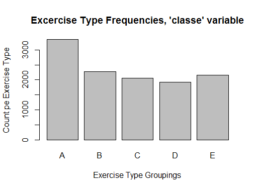

```r
plot(clean_train_set$classe, main = "Excercise Type Frequencies, 'classe' variable", xlab = "Exercise Type Groupings", ylab = "Count pe Exercise Type")
```

## Building the Predictive Model

```r
clean_training <- createDataPartition(y = clean_train_set$classe, p=0.6, list=FALSE)
model_train_set <- clean_train_set[clean_training, ]
model_test_set <- clean_train_set[-training, ]
```

Using the Random Forest method and 4 fold cross validation, we will build a training model to predict the ‘classe’ on the remaining test set.

```r
model <-train(model_train_set$classe~., method = "rf", data = model_train_set, trControl = trainControl(method = "cv", number = 4, allowParallel = TRUE))

print(model)
```

```
 Random Forest

 7067 samples
   53 predictor
    5 classes: 'A', 'B', 'C', 'D', 'E'

 No pre-processing
 Resampling: Cross-Validated (4 fold)

 Summary of sample sizes: 5299, 5300, 5300, 5302

 Resampling results across tuning parameters:

   mtry  Accuracy   Kappa      Accuracy SD  Kappa SD
    2    0.9830192  0.9785123  0.004262802  0.005397246
   27    0.9903776  0.9878275  0.003396666  0.004297766
   53    0.9845768  0.9804900  0.002743560  0.003472060

 Accuracy was used to select the optimal model using  the largest value.
 The final value used for the model was mtry = 27.
```

### In Sample Accuracy

We run predict on the training set data with the train model we just built. Then we calculate the In Sample Accuracy which is the accuracy of our prediciton model on the training data set.

```r
predictions <- predict(model, model_train_set)
confusionMatrix(predictions, model_train_set$classe)
```

```
 Confusion Matrix and Statistics

           Reference
 Prediction    A    B    C    D    E
          A 2009    0    0    0    0
          B    0 1368    0    0    0
          C    0    0 1233    0    0
          D    0    0    0 1158    0
          E    0    0    0    0 1299

 Overall Statistics

                Accuracy : 1
                  95% CI : (0.9995, 1)
     No Information Rate : 0.2843
     P-Value [Acc > NIR] : < 2.2e-16

                   Kappa : 1
  Mcnemar's Test P-Value : NA

 Statistics by Class:

                      Class: A Class: B Class: C Class: D Class: E
 Sensitivity            1.0000   1.0000   1.0000   1.0000   1.0000
 Specificity            1.0000   1.0000   1.0000   1.0000   1.0000
 Pos Pred Value         1.0000   1.0000   1.0000   1.0000   1.0000
 Neg Pred Value         1.0000   1.0000   1.0000   1.0000   1.0000
 Prevalence             0.2843   0.1936   0.1745   0.1639   0.1838
 Detection Rate         0.2843   0.1936   0.1745   0.1639   0.1838
 Detection Prevalence   0.2843   0.1936   0.1745   0.1639   0.1838
 Balanced Accuracy      1.0000   1.0000   1.0000   1.0000   1.0000
```

We get an accuracy of 100% on the training data.

### Out of Sample Accuracy

Run the model on the test set

```r
test_predictions <- predict(model, model_test_set)
confusionMatrix(test_predictions, model_test_set$classe)
```

```
 Confusion Matrix and Statistics

           Reference
 Prediction    A    B    C    D    E
          A 1334    1    0    0    0
          B    0  916    3    0    0
          C    0    1  819    1    0
          D    0    0    0  766    2
          E    0    0    0    1  879

 Overall Statistics

                Accuracy : 0.9981
                  95% CI : (0.9964, 0.9991)
     No Information Rate : 0.2824
     P-Value [Acc > NIR] : < 2.2e-16

                   Kappa : 0.9976
  Mcnemar's Test P-Value : NA

 Statistics by Class:

                      Class: A Class: B Class: C Class: D Class: E
 Sensitivity            1.0000   0.9978   0.9964   0.9974   0.9977
 Specificity            0.9997   0.9992   0.9995   0.9995   0.9997
 Pos Pred Value         0.9993   0.9967   0.9976   0.9974   0.9989
 Neg Pred Value         1.0000   0.9995   0.9992   0.9995   0.9995
 Prevalence             0.2824   0.1944   0.1740   0.1626   0.1865
 Detection Rate         0.2824   0.1939   0.1734   0.1622   0.1861
 Detection Prevalence   0.2827   0.1946   0.1738   0.1626   0.1863
 Balanced Accuracy      0.9999   0.9985   0.9979   0.9984   0.9987
```

### Prediction Assignment

Run the prediction model on the clean data set that was kept separate during the training and testing phases.

```r
results <- predict(model, clean_test_set)
answers <- as.character(results)
print(answers)
```

```
  [1] "B" "A" "B" "A" "A" "E" "D" "B" "A" "A" "B" "C" "B" "A" "E" "E" "A"
 [18] "B" "B" "B"
```

```r
pml_write_files = function(x){
  n = length(x)
  for(i in 1:n){
    filename = paste0("problem_id_",i,".txt")
    write.table(x[i],file=filename,quote=FALSE,row.names=FALSE,col.names=FALSE)
  }
}

pml_write_files(answers)
```